# TOMBOLA

## Simulatore TOMBOLA! in Python

Durante le feste natalizie, ho avuto il piacere di giocare a tombola con i miei familiari, e durante una discussione ci si è ritrovati a parlare di questo gioco: mio zio infatti, sosteneva che le ci fossero cartelle fortunate, le quali vincessero il maggior numero delle volte rispetto alle altre. Dopo vari tentativi più o meno convincenti, mio zio rimaneva ancora fermo sulla sua idea, e la discussione si è arenata al terzo giro di brindisi. Dopo i festeggiamenti però mi è tornato in mente questo fatto, e quindi ho voluto simulare il gioco della TOMBOLA, in modo da dare dati empirici sulla percentuale di vittorie di ogni cartella.

### Teoria e risultati attesi:

Vengono importati i metodi utilizzati in questo progetto, tra cui i famosissimi numpy,random e math. Il metodo più particolare utilizzato è copy, che permette di creare una copia virtuale di un array, in modo da poterlo modificare senza andare a cambiare il vettore delle informazioni.

```python
import math
import random
from statistics import mean
import numpy as np
from random import shuffle
import matplotlib.pyplot as plt
import copy
```

La classe 'Tombola' verrà utilizzata per la simulazione del gioco, ed è composta da 5 metodi:

#### Cartelle:

è il metodo utilizzato per la creazione delle cartelle: si generano un numero di cartelle a scelta, le quali verranno riempite con 15 numeri casuali, come avviene nella tombola reale.

#### Estrazione:

è il metodo utilizzato per arrivare all'estrazione dei numeri: serviva infatti la sequenza con cui i numeri venivano estratti, così è stata creato un vettore contenente numeri casuali da 1 a 90, come avviene nella tombola tradizionale.

#### Check:

è il metodo utilizzato per verificare se il numero estratto è presente nella cartella: la base del gioco della tombola insomma. Per ogni numero estratto quindi, si è controllato ogni numero in ogni cartella per vedere se era presente. Quando il numero è pr#esente, si verifica se la cartella ha fatto Tombola o meno, in caso contrario si procede alla prossima cartella.

### Tabellone:

#### Statistiche:

è il metodo utilizzato per mostrare le percentuali di vittoria di ogni cartella: con un grafico a torta le porzioni e le percentuali di vittoria di ogni cartella.

```python
class Tombola:
    def Cartelle(numero):
        numeri = []
        cartelle = [ [] for _ in range(numero) ]
        for i in range(1,91):
            numeri.append(i)
        for i in range(0,len(cartelle)):
            cartelle[i] = np.random.choice(numeri,15,replace=False)
            cartelle[i].sort()
            cartelle[i] = cartelle[i].tolist()
        return cartelle

    def Estrazione():
        numeri = []
        for i in range(1,91):
            numeri.append(i)
        shuffle(numeri)
        return numeri

    def Check(cartelle_, estrazione_):
        cartelle = copy.deepcopy(cartelle_)
        estrazione = estrazione_
        score = 0
        numero_cartella = 0
        numero_casella = 0
        for numero in estrazione:
            for cartella in cartelle:
                for casella in cartella:
                    if (casella == numero):
                        cartella[numero_casella] = 0
                    numero_casella = numero_casella+1
                for casella in cartella:
                    if(casella == 0):
                        score = score +1
                if (score == 15):
                    return(numero_cartella)
                    break
                else:
                    score = 0
                numero_casella = 0
                numero_cartella = numero_cartella + 1
            numero_cartella = 0


    def Tabellone(risultati,cartella):
        scoreboard = []
        for i in range(0,cartella):
            scoreboard.append([i,0])
        for i in scoreboard:
            for x in risultati:
                if(i[0]==x):
                    i[1] = i[1]+1
        valori = [i[1] for i in scoreboard]
        print("\nPunteggi: {} \n".format(scoreboard))

    def Statistiche(risultati,cartella):
        labels = ["Cartella {}".format(i) for i in range(0,cartella)]
        scoreboard = []
        for i in range(0,cartella):
            scoreboard.append([i,0])
        for i in scoreboard:
            for x in risultati:
                if(i[0]==x):
                    i[1] = i[1]+1
        plt.figure(1)
        plt.subplot(221)
        plt.title('Tabellone punteggi')
        plt.ylabel('Numero Vittorie')
        plt.xlabel('Cartelle')
        for i in range(0,len(scoreboard)):
            plt.bar(scoreboard[i][0],height=scoreboard[i][1])
        #plt.show()
        plt.subplot(222)
        sizes = [i[1] for i in scoreboard]
        patches, texts = plt.pie(sizes, shadow=True, startangle=90)
        plt.title("Statistiche:")
        plt.pie(sizes, labels=labels, autopct='%1.1f%%', shadow=True, startangle=140)
        plt.subplot(222)
        #plt.legend(patches, labels, loc="right") #vedere dove mettere sta medda qua che non si capisce

        plt.axis('equal')
        plt.tight_layout()



        plt.show()
```

Dopo la creazione della classe, si crea la simulazione vera e propria:

[output not shown]

[figure not shown]

```python
x = 0
lunghezza = 1000
n_cartelle = 10

cartella = Tombola.Cartelle(n_cartelle)
estrazioni = []
risultati = []
cartelle_ = []

for numero in range(1,lunghezza+1):
    estrazioni.append(Tombola.Estrazione())
    cartelle_.append(cartella)
print("Numero estrazioni: {}".format(len(estrazioni)))
while (x < lunghezza):
    print('\r{0}% cartelle visionate! {1} su {2}...'.format(round(x/lunghezza)*100,x+1,lunghezza), end='')
    risultati.append(Tombola.Check(cartelle_[x],estrazioni[x]))
    x = x+1
Tombola.Tabellone(risultati,n_cartelle)
```

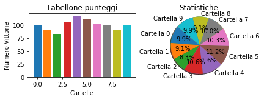

```python
Tombola.Statistiche(risultati,n_cartelle)
```